# Sleep quality and cognitve performance analysis

Tamas Nagy

October 29, 2019

# Aim

We want to investigate the effect of poor sleep quality on cognitive performance. Two sleep quality questionnaires and several cognitive tests were administered across three studies.

First, we want to aggregate the sleep quality questionnaires into one sleep quality metric. Then we want to investigate the association while controlling for the potential effect of the separate studies, and potential confounders (gender, age, morningness score). Subsequently, we want to obtain Bayes Factors, so we can draw conclusions about the probability of null or alternative hypothesis.

```r
df_raw <- read_csv2("data/rawdata_hungarian.csv",
                    locale = locale(encoding = "WINDOWS-1252"))

# Process data for ease of use
# Clean variable names: Remove spaces, accented characters, capitals, make smallcase
# Translate Hungarian variable names, recode sex

df <-
  df_raw %>%
  janitor::clean_names() %>% # Remove spaces, accented characters, capitals
  rename(id = sorszam,
         sex = nem,
         age = eletkor,
         education_yrs = iskolazottsag,
         own_income = `sajat_gazdasagi_helyzet`) %>%
  mutate(sex = case_when(study == 3 & sex == 0 ~ "Male",
                         study == 3 & sex == 1 ~ "Female",
                         study %in% c(1,2) & sex == 1 ~ "Male",
                         study %in% c(1,2) & sex == 2 ~ "Female",
                         TRUE ~ NA_character_)
         )
```

# Demographics

```r
df %>%
  add_count(study) %>%
  mutate(sex_female = sex == "Female") %>%
  group_by(study, n) %>%
  summarise_at(vars(age, sex_female, education_yrs, meq_all, ais_ossz, psqi_osszpont, groningen_ossz, diary_psqi4f),
               list(mean = mean, sd = sd), na.rm = TRUE) %>%
  mutate(male = (1 - sex_female_mean) * n,
         female = sex_female_mean * n) %>%
  select(-starts_with("sex_female")) %>%
  select(sort(names(.))) %>%
  DT::datatable(
    extensions = 'Buttons',
    options = list(dom = 'Bfrtip',
                   buttons = c('excel', "csv"))) %>%
  formatRound(columns = c("age_mean", "education_yrs_mean", "meq_all_mean", "ais_ossz_mean", "psqi_osszpont_mean","groningen_ossz_mean","diary_psqi4f_mean","age_sd", "education_yrs_sd", "meq_all_sd", "ais_ossz_sd", "psqi_osszpont_sd","groningen_ossz_sd","diary_psqi4f_sd"),
              digits = 2)
```

|  | age_mean | age_sd | ais_ossz_mean | ais_ossz_sd | diary_psqi4f_mean | diary_psqi4f_sd | education_yrs_mean | education_yrs_sd | female | groningen_ossz_mean | groningen_ossz_sd | male | meq_all_mean | meq_all_sd | n | psqi_osszpont_mean | psqi_osszpont_sd | study |
| --- | --- | --- | --- | --- | --- | --- | --- | --- | --- | --- | --- | --- | --- | --- | --- | --- | --- | --- |
| 1 | 21.3829787234043 | 1.78828544907225 | 4.27659574468085 | 2.75603785911062 |  |  | 14.3617021276596 | 1.5766713963131 | 37 |  |  | 10 | 34.9574468085106 | 6.6918426876976 | 47 | 3.59574468085106 | 1.56954125765523 | 1 |
| 2 | 21.621359223301 | 2.00057102071114 | 3.45631067961165 | 2.17731935847877 | 1.37755102040816 | 1.22276774204193 | 14.504854368932 | 1.73698965650892 | 73 | 2.86407766990291 | 2.87330015797685 | 30 | 33.9902912621359 | 6.31291105535046 | 103 | 2.56310679611651 | 1.27317653468903 | 2 |
| 3 | 20.9882352941176 | 1.68674184130699 | 4.42352941176471 | 3.04089770027362 |  |  | 14.2764705882353 | 1.5895976623949 | 62 |  |  | 23 | 33.6117647058824 | 5.68434382368646 | 85 | 3.12941176470588 | 1.77138790953603 | 3 |

# Principal component analysis of sleep quality

We conduct a principal component analysis (PCA) to aggregate the two sleep quality measures into one.

```r
sleepd_pca <-
  df %>%
  select(ais_ossz, psqi_osszpont) %>%
  psych::pca(nfactors = 1)

# Show PCA result
sleepd_pca
```

```
## Principal Components Analysis
## Call: principal(r = r, nfactors = nfactors, residuals = residuals,
##     rotate = rotate, n.obs = n.obs, covar = covar, scores = scores,
##     missing = missing, impute = impute, oblique.scores = oblique.scores,
##     method = method, use = use, cor = cor, correct = 0.5, weight = NULL)
## Standardized loadings (pattern matrix) based upon correlation matrix
##                PC1   h2   u2 com
## ais_ossz      0.89 0.79 0.21   1
## psqi_osszpont 0.89 0.79 0.21   1
##
##                 PC1
## SS loadings    1.57
## Proportion Var 0.79
##
## Mean item complexity =  1
## Test of the hypothesis that 1 component is sufficient.
##
## The root mean square of the residuals (RMSR) is  0.21
##  with the empirical chi square  21.44  with prob <  NA
##
## Fit based upon off diagonal values = 0.86
```

```r
bartlett_result <-
  df %>%
  select(ais_ossz, psqi_osszpont) %>%
  cor() %>%
  psych::cortest.bartlett(n = 235)

# Add the PC to the original data
df <-
  df %>%
  mutate(sleep_disturb = sleepd_pca$scores[,1])
```

# Distribution of sleep quality questionnaires (original and the one derived from PCA)

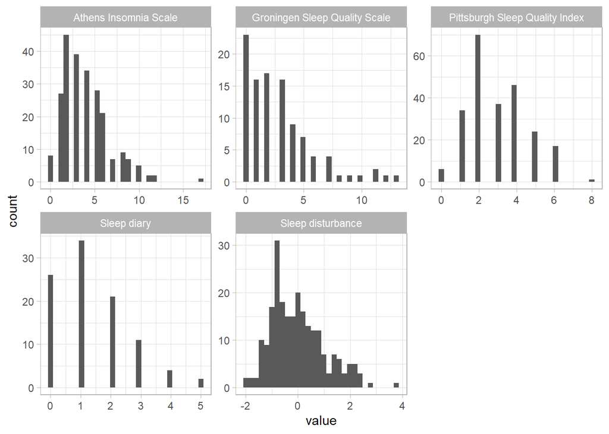

```r
df %>%
  select(one_of(sleep_variables), sleep_disturb) %>%
  gather(measure, value) %>%
  mutate(measure = recode(measure, !!!variables_recode)) %>%
  ggplot() +
  aes(x = value) +
  geom_histogram() +
  facet_wrap(~measure, scales = "free") +
  theme_light()
```

# Exploraton of important variables

```r
skimr::skim_with(numeric = list(hist = NULL)) # Remove spark histograms
```

```
## Creating new skimming functions for the following classes: hist.
## They did not have recognized defaults. Call get_default_skimmers() for more information.
```

[output not shown]

```r
df %>%
  select(variables_needed) %>%
  skimr::skim_to_wide() %>%
  DT::datatable(
    extensions = 'Buttons',
    options = list(dom = 'Bfrtip',
                   buttons = c('excel', "csv")))
```

```
## Note: Using an external vector in selections is ambiguous.
## i Use `all_of(variables_needed)` instead of `variables_needed` to silence this message.
## i See <https://tidyselect.r-lib.org/reference/faq-external-vector.html>.
```

|  | skim_type | skim_variable | n_missing | complete_rate | numeric.mean | numeric.sd | numeric.p0 | numeric.p25 | numeric.p50 | numeric.p75 | numeric.p100 | numeric.hist |
| --- | --- | --- | --- | --- | --- | --- | --- | --- | --- | --- | --- | --- |
| 1 | numeric | RT Triplet learning | 0 | 1 | 26.4780212765957 | 26.2718648625149 | -6 | 13.3125 | 20.5 | 32.6575 | 239 | ▇▁▁▁▁ |
| 2 | numeric | ACC Triplet learning | 0 | 1 | 0.0395 | 0.0356875388245032 | -0.02 | 0.01625 | 0.03 | 0.05 | 0.2 | ▇▇▂▁▁ |
| 3 | numeric | ACC Higher-order sequence learning | 0 | 1 | 0.0163191489361702 | 0.034011754116423 | -0.05 | -0.0025 | 0.01 | 0.03 | 0.21 | ▇▇▂▁▁ |
| 4 | numeric | RT Higher-order sequence learning | 0 | 1 | 16.6303191489362 | 40.3351401508344 | -23 | -1.69 | 6 | 18.815 | 259.75 | ▇▁▁▁▁ |
| 5 | numeric | ACC Statistical learning | 0 | 1 | 0.0275212765957447 | 0.0301022043672062 | -0.09 | 0.01 | 0.0225 | 0.04 | 0.13 | ▁▁▇▂▁ |
| 6 | numeric | RT Statistical learning | 0 | 1 | 16.7388936170213 | 9.94137580169438 | -9 | 9.63 | 15.5 | 22.6275 | 50.25 | ▁▇▇▂▁ |
| 7 | numeric | Average ACC | 0 | 1 | 0.896255319148936 | 0.0969118173677357 | 0.4 | 0.88 | 0.93 | 0.96 | 0.99 | ▁▁▁▂▇ |
| 8 | numeric | ACC general skill learning | 0 | 1 | -0.021063829787234 | 0.0906961217838865 | -0.64 | -0.04 | 0.01 | 0.03 | 0.13 | ▁▁▁▂▇ |
| 9 | numeric | RT average | 0 | 1 | 359.875957446809 | 40.9363674468286 | 258.5 | 330.375 | 359.5 | 390.02 | 460.13 | ▂▆▇▇▂ |
| 10 | numeric | RT general skill learning | 0 | 1 | 31.1286382978723 | 30.1464795866976 | -52.33 | 10.17 | 27.17 | 46.335 | 155.67 | ▁▇▅▂▁ |

[output cut: 8 more lines]

# Investigation of the association between chronotype with sleep and cognitive performance

```r
df %>%
  select(starts_with("meq"),
         sleep_disturb,
         one_of(variables_needed),
         -study, -diary_psqi4f, -groningen_ossz) %>%
  correlate(use = "complete.obs", method = "spearman") %>%
  fashion() %>%
  DT::datatable(
    extensions = 'Buttons',
    options = list(dom = 'Bfrtip',
                   buttons = c('excel', "csv")))
```

```
##
## Correlation method: 'spearman'
## Missing treated using: 'complete.obs'
```

|  | rowname | meq_morningalert | meq_timepref | meq_all | sleep_disturb | trip_learn_all_rt | trip_learn_all_acc | highrer_order_acc | highrer_order_rt | stat_learn_acc | stat_learn_rt | acc_avg | acc_gs | rt_avg | rt_gs_1min4 | cs_avg | wcst_pers_error | ais_ossz | psqi_osszpont |
| --- | --- | --- | --- | --- | --- | --- | --- | --- | --- | --- | --- | --- | --- | --- | --- | --- | --- | --- | --- |
| 1 | meq_morningalert |  | .40 | .73 | -.23 | .05 | -.07 | -.05 | .05 | -.05 | -.05 | .09 | .03 | .04 | -.04 | .08 | .05 | -.22 | -.19 |
| 2 | meq_timepref | .40 |  | .91 | -.14 | .05 | -.01 | -.01 | .01 | -.03 | .12 | -.02 | -.02 | .10 | -.07 | -.05 | .08 | -.16 | -.08 |
| 3 | meq_all | .73 | .91 |  | -.22 | .06 | -.04 | -.03 | .03 | -.05 | .06 | .03 | .00 | .08 | -.06 | -.01 | .10 | -.23 | -.16 |
| 4 | sleep_disturb | -.23 | -.14 | -.22 |  | -.07 | -.01 | -.04 | .00 | -.03 | -.07 | -.06 | .01 | -.05 | -.12 | -.01 | .03 | .87 | .88 |
| 5 | trip_learn_all_rt | .05 | .05 | .06 | -.07 |  | .16 | .17 | .68 | .07 | .59 | .27 | .27 | -.26 | .17 | .10 | -.11 | -.03 | -.08 |
| 6 | trip_learn_all_acc | -.07 | -.01 | -.04 | -.01 | .16 |  | .36 | .20 | .70 | .04 | -.50 | -.15 | -.04 | -.02 | .10 | -.00 | .01 | -.06 |
| 7 | highrer_order_acc | -.05 | -.01 | -.03 | -.04 | .17 | .36 |  | .17 | -.29 | .09 | -.31 | -.01 | -.03 | .09 | .16 | -.04 | -.01 | -.08 |
| 8 | highrer_order_rt | .05 | .01 | .03 | .00 | .68 | .20 | .17 |  | .12 | -.07 | .22 | .22 | -.22 | .14 | .10 | -.09 | .03 | -.03 |
| 9 | stat_learn_acc | -.05 | -.03 | -.05 | -.03 | .07 | .70 | -.29 | .12 |  | -.02 | -.31 | -.13 | -.05 | -.05 | .01 | .01 | -.01 | -.04 |
| 10 | stat_learn_rt | -.05 | .12 | .06 | -.07 | .59 | .04 | .09 | -.07 | -.02 |  | .12 | .16 | -.15 | .07 | -.05 | -.03 | -.05 | -.06 |

[output cut: 8 more lines]

From the demographic confounders, we will use gender and age. From sleep related confounders, morningness (meq_all) was used as a confounder. We didn’t include any socioeconomic confounders, because this data was missing for a large number of participants.

# Checking hypotheses

First, we create several linear mixed-effects models (LMEM) with the same predictors (ais, psqi, or sleep disturbance), and the cognitive performance metrics as outcomes (Bates et al. 2015). The LMEM contains a random intercept term by study to account for the potential differences between studies.

After we ran the models, the residuals did not show normal distribution. Therefore we recalculated the estimates using 1000 parametric bootstrap samples (Canty and Ripley 2019; Davison and Hinkley 1997). Bootstrapped 95% confidence intervals were obtained, and p values were calculated based on these.

In order to make prediction about the likelihood of the null hypothesis - as compared to the alternative hypothesis - we calculated the Bayes Factor (Wagenmakers 2007). To calculate the BIC derived Bayes Factor, we calculated the Bayesian Information Criterion (BIC) for null models that included a fixed intercept, and the confounders (gender, age, morningness score), and a random intercept term by study. Maximum Likelihood estimation was used so the models could be compared. The $BF_{01}$ were calculated based on Wagenmakers (2007). As all BFs were over 3, we can conclude that the cognitive performance of the study population seems to be unaffected by poor sleep.

```r
# Reshaping data into long format, so we have a dataset for all combinations of outcome and predictor variables
study_long <-
  df %>%
  select(one_of(variables_needed), -one_of(sleep_variables), sleep_disturb, study,
         ais_ossz, psqi_osszpont, one_of(confounders)) %>%
  gather(outcome_var, out_value, -ais_ossz, -psqi_osszpont, -sleep_disturb,             -one_of(confounders), -study,
         na.rm = TRUE) %>%
  gather(predictor_var, pred_value, ais_ossz, psqi_osszpont, sleep_disturb, -one_of(confounders), -study) %>%
  group_nest(outcome_var, predictor_var)

# Calculate random intercept models by study for each outcome variable. Predictor variables are ais or psqi or sleep disturbance. Confounders (gender, age, morningness score) are also added, and null models that contain only the confounders are also created.

study_models <-
  study_long %>%
  mutate(model = map(data,
                     ~lmer(scale(out_value) ~ scale(pred_value) + (1|study) + scale(meq_all) + sex + age,
                            REML = FALSE,
                            data = .x)),
         null_model = map(data,
                     ~lmer(scale(out_value) ~ 1 + (1|study) + scale(meq_all) + sex + age,
                            REML = FALSE,
                            data = .x)),
         df = map_int(model, df.residual)
         )
```

[output not shown]

```r
# Calculating the bootstrapped estimates and p values

boot_models <-
  study_models %>%
  mutate(bootstrap = future_map(model, ~bootMer(x = .x,
                                                FUN = fixef,
                                                verbose = FALSE,
                                                nsim = 1000)),
         boot_ci = map(bootstrap, ~boot.ci(boot.out = .x,
                                           type = "perc",
                                           index = 2)),
         boot_estimate = map_dbl(boot_ci, ~.x$t0),
         boot_low = map_dbl(boot_ci, ~.x$percent[1, 4]),
         boot_high = map_dbl(boot_ci, ~.x$percent[1, 5]),
         boot_p = pmap_dbl(list(boot_estimate, boot_low, boot_high),
                           ~p_from_95_conf(..1, ..2, ..3))
  )


boot_models %>%
  mutate(model = map(model, ~glance(.x)),
         null_model = map(null_model, ~glance(.x))) %>%
  unnest(c(model, null_model), names_sep = "_") %>%
  mutate(BF01 = exp((model_BIC - null_model_BIC)/2) %>% round(4)) %>%
  mutate_at(vars(outcome_var, predictor_var),
            ~recode(., !!!variables_recode)) %>%
  left_join(variable_groups, ., by = "outcome_var") %>%
  select(group, outcome_var, predictor_var,
         estimate = boot_estimate,
         df,
         ci_low = boot_low, ci_high = boot_high,
         p = boot_p,
         BF01) %>%
  arrange(predictor_var, group, outcome_var) %>%
  DT::datatable(
    extensions = 'Buttons',
    options = list(dom = 'Bfrtip',
                   buttons = c('excel', "csv"))) %>%
  formatRound(columns = c("estimate", "ci_low", "ci_high","p","BF01"), digits = 4)
```

|  | group | outcome_var | predictor_var | estimate | df | ci_low | ci_high | p | BF01 |
| --- | --- | --- | --- | --- | --- | --- | --- | --- | --- |
| 1 | ACC learning indices | ACC Higher-order sequence learning | Athens Insomnia Scale | -0.0395200607939968 | 205 | -0.176501465809473 | 0.0984066043940264 | 0.5731 | 12.3546 |
| 2 | ACC learning indices | ACC Statistical learning | Athens Insomnia Scale | -0.0315759135664116 | 205 | -0.168728969154394 | 0.101051002673218 | 0.6464 | 12.96 |
| 3 | ACC learning indices | ACC Triplet learning | Athens Insomnia Scale | -0.0681068835913253 | 205 | -0.187273209923481 | 0.0446022765170251 | 0.2496 | 7.9512 |
| 4 | General skill indices | ACC general skill learning | Athens Insomnia Scale | 0.0566317410370652 | 205 | -0.0382716863149636 | 0.148626549601706 | 0.2349 | 7.2149 |
| 5 | General skill indices | Average ACC | Athens Insomnia Scale | 0.0781442575518723 | 205 | -0.0243155638860078 | 0.186827086087715 | 0.1468 | 4.4736 |
| 6 | General skill indices | RT average | Athens Insomnia Scale | 0.0144474405557727 | 205 | -0.123798337772027 | 0.149439291492866 | 0.8358 | 14.2437 |
| 7 | General skill indices | RT general skill learning | Athens Insomnia Scale | -0.0285449674138126 | 205 | -0.168686417000678 | 0.105430880533971 | 0.6831 | 13.4696 |
| 8 | RT learning indices | RT Higher-order sequence learning | Athens Insomnia Scale | 0.0447831959041943 | 205 | -0.0942287202901007 | 0.178788502888116 | 0.5202 | 12.0127 |
| 9 | RT learning indices | RT Statistical learning | Athens Insomnia Scale | -0.0467334792097151 | 205 | -0.180985351508756 | 0.10074564649954 | 0.5155 | 11.9647 |
| 10 | RT learning indices | RT Triplet learning | Athens Insomnia Scale | 0.00035941073254364 | 205 | -0.142698725231175 | 0.141301008523014 | 0.996 | 14.56 |

[output cut: 26 more lines]

The LMEMs show no evidence that cognitive performance metrics were affected by poor sleep quality.

# Visualize the association with sleep disturbance for each outcome measure

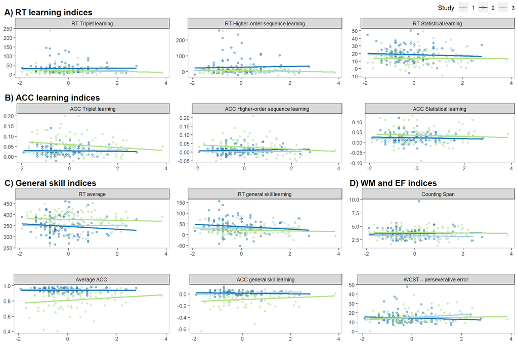

```r
# Create a plot
plot_df <-
  df %>%
  # Use pretty variable names
  select(variables_needed) %>%
  # Put data into long format so the outcome vriable can be faceted
  gather(outcome_var, value, -`Sleep disturbance`, -study) %>%
  # Add variable group names
  left_join(variable_groups, by = "outcome_var")

# Create a plotting function for all groups separately
plot_single <- function(outcome_name){
  plot_df %>%
    filter(outcome_var == outcome_name) %>%
    ggplot() +
    aes(x = `Sleep disturbance`, y = value, color = as.factor(study)) +
    geom_point(alpha = .5) +
    geom_smooth(method = "lm", se = FALSE) +
    scale_color_brewer(palette = "Paired") +
    facet_wrap(~outcome_var, scales = "free_y") +
    labs(title = NULL, x = NULL, y = NULL) +
    theme_bw() +
    theme(legend.position = "none",
          panel.grid.major = element_blank(),
          panel.grid.minor = element_blank(),
          panel.background = element_blank()) +
    cowplot::panel_border()
}

# Put all rows of the plot into a list
single_plots <-
  map(unique(plot_df$outcome_var), plot_single)

# Create one plot to get the legend
plot_1 <-
  plot_df %>%
  filter(outcome_var == "RT Triplet learning") %>%
  ggplot() +
  aes(x = `Sleep disturbance`, y = value, color = as.factor(study)) +
  geom_point(alpha = .5) +
  geom_smooth(method = "lm", se = FALSE) +
  scale_color_brewer(palette = "Paired") +
  labs(color = "Study") +
  theme(legend.direction = "horizontal",
        legend.justification = "right",
        legend.box.just = "top",
        legend.box.margin = margin())

# Get legend
plot_legend <- cowplot::get_legend(plot_1)

# Assemble the plot.
# I realize that the code is a bit ugly, but the outcome seems acceptable
plot_grid(
  NULL, NULL, plot_legend,
  single_plots[[1]], single_plots[[4]], single_plots[[6]],
  NULL, NULL, NULL,
  single_plots[[2]], single_plots[[3]], single_plots[[5]],
  NULL, NULL, NULL,
  single_plots[[9]], single_plots[[10]],single_plots[[11]],
  NULL, NULL, NULL,
  single_plots[[7]], single_plots[[8]], single_plots[[12]],
  labels = c(
    "", "", "",
    "A) RT learning indices", "", "",
    "", "", "",
    "B) ACC learning indices", "", "",
    "", "", "",
    "C) General skill indices", "", "D) WM and EF indices",
    "", "", "",
    "", "", ""),
  hjust = -.05,
  vjust = .05,
  nrow = 8,
  rel_heights = c(.20, 1, .15, 1, .15, 1, .15, 1)
) +
  geom_segment(y = .74, yend = .74, x = .02, xend = .98, size = 1.1) +
  geom_segment(y = .49, yend = .49, x = .02, xend = .98, size = 1.1) +
  geom_segment(y = .02, yend = .49, x = .668, xend = .668, size = 1.1) +
  NULL
```

# Calculating associations between sleep diary answers, GSQI, and the executing functions

We used robust linear regression to model the relationship between sleep diary answers, QSQI score, and the executive functions. We calculated the BF in the previously described way.

```r
study2_long <-
  df %>%
  filter(study == 2) %>%
  select(one_of(variables_needed), -one_of(sleep_variables), -sleep_disturb, -study,
         groningen_ossz, diary_psqi4f, one_of(confounders)) %>%
  gather(outcome_var, out_value, -groningen_ossz, -diary_psqi4f, -one_of(confounders),
         na.rm = TRUE) %>%
  gather(predictor_var, pred_value, groningen_ossz, diary_psqi4f, -one_of(confounders)) %>%
  drop_na(pred_value, out_value) %>%
  group_nest(outcome_var, predictor_var)

# Get null BICs
study2_nullBIC <-
  study2_long %>%
  mutate(model = map(data, ~MASS::rlm(scale(out_value) ~ 1 + scale(meq_all) + sex + age,
                                data = .x) %>%
                           glance(.) %>%
                           select(nullBIC = BIC))) %>%
  unnest(model) %>%
  select(-data)


study2_models <-
  study2_long %>%
  mutate(model = map(data, ~MASS::rlm(scale(out_value) ~ scale(pred_value) + scale(meq_all) + sex + age,
                                data = .x)),
         df = map_int(data, ~nrow(.x)) - 1)

# Show predictors
study2_models %>%
  mutate(model = map(model, ~tidy(.x))) %>%
  unnest(model) %>%
  filter(str_detect(term, "pred_value")) %>%
  mutate_at(vars(outcome_var, predictor_var),
            ~recode(., !!!variables_recode)) %>%
  left_join(variable_groups, ., by = "outcome_var") %>%
  select(group, everything(), -term, -data) %>%
  mutate(ci_low = estimate - std.error*1.96,
         ci_high = estimate + std.error*1.96,
         p = 2*pt(q = -abs(statistic),
                  df = df)) %>%
  arrange(predictor_var, group, outcome_var) %>%
  DT::datatable(
    extensions = 'Buttons',
    options = list(dom = 'Bfrtip',
                   buttons = c('excel', "csv"))) %>%
  formatRound(columns=c("estimate", "std.error", "statistic", "ci_low", "ci_high", "p"), digits = 4)
```

|  | group | outcome_var | predictor_var | estimate | std.error | statistic | df | ci_low | ci_high | p |
| --- | --- | --- | --- | --- | --- | --- | --- | --- | --- | --- |
| 1 | ACC learning indices | ACC Higher-order sequence learning | Groningen Sleep Quality Scale | 0.0285895694350212 | 0.102763710916942 | 0.278206860962119 | 102 | -0.172827303962186 | 0.230006442832228 | 0.781416747409381 |
| 2 | ACC learning indices | ACC Statistical learning | Groningen Sleep Quality Scale | -0.00137395068672864 | 0.103679992854611 | -0.0132518400985551 | 102 | -0.204586736681767 | 0.201838835308309 | 0.989452756256499 |
| 3 | ACC learning indices | ACC Triplet learning | Groningen Sleep Quality Scale | 3.59950043388433e-05 | 0.101913837903286 | 0.000353190548794776 | 102 | -0.199715127286101 | 0.199787117294779 | 0.999718884562437 |
| 4 | General skill indices | ACC general skill learning | Groningen Sleep Quality Scale | 0.040164890581618 | 0.088798004216264 | 0.45231749222424 | 102 | -0.133879197682259 | 0.214208978845495 | 0.652000779241599 |
| 5 | General skill indices | Average ACC | Groningen Sleep Quality Scale | 0.155795476102753 | 0.106291146054183 | 1.46574274421065 | 102 | -0.0525351701634452 | 0.364126122368951 | 0.145794359107909 |
| 6 | General skill indices | RT average | Groningen Sleep Quality Scale | -0.176189609869576 | 0.108986331227601 | -1.61662116602156 | 102 | -0.389802819075674 | 0.0374235993365217 | 0.10904883521657 |
| 7 | General skill indices | RT general skill learning | Groningen Sleep Quality Scale | -0.10409272515947 | 0.100183763879408 | -1.03901791197192 | 102 | -0.300452902363108 | 0.0922674520441693 | 0.301253137329446 |
| 8 | RT learning indices | RT Higher-order sequence learning | Groningen Sleep Quality Scale | -0.00367694541253452 | 0.0526060803158762 | -0.0698958255482274 | 102 | -0.106784862831652 | 0.0994309720065828 | 0.944413426123409 |
| 9 | RT learning indices | RT Statistical learning | Groningen Sleep Quality Scale | -0.104926017809009 | 0.107857645256419 | -0.972819474776775 | 102 | -0.31632700251159 | 0.106474966893572 | 0.332944411997453 |
| 10 | RT learning indices | RT Triplet learning | Groningen Sleep Quality Scale | -0.053566606990332 | 0.0618597199971387 | -0.865936783949389 | 102 | -0.174811658184724 | 0.0676784442040598 | 0.38855709334052 |

[output cut: 14 more lines]

```r
# Calculate BF
study2_models %>%
  mutate(model = map(model, ~glance(.x))) %>%
  unnest(model) %>%
  left_join(study2_nullBIC, by = c("outcome_var", "predictor_var")) %>%
  mutate(BF01 = exp((BIC - nullBIC)/2) %>% round(4)) %>%
  mutate_at(vars(outcome_var, predictor_var),
            ~recode(., !!!variables_recode)) %>%
  left_join(variable_groups, ., by = "outcome_var") %>%
  select(group, outcome_var, predictor_var, BF01) %>%
  arrange(predictor_var, group, outcome_var) %>%
  DT::datatable(
    extensions = 'Buttons',
    options = list(dom = 'Bfrtip',
                   buttons = c('excel', "csv"))) %>%
  formatRound(columns = c("BF01"), digits = 4)
```

|  | group | outcome_var | predictor_var | BF01 |
| --- | --- | --- | --- | --- |
| 1 | ACC learning indices | ACC Higher-order sequence learning | Groningen Sleep Quality Scale | 10.8684 |
| 2 | ACC learning indices | ACC Statistical learning | Groningen Sleep Quality Scale | 10.0814 |
| 3 | ACC learning indices | ACC Triplet learning | Groningen Sleep Quality Scale | 10.1498 |
| 4 | General skill indices | ACC general skill learning | Groningen Sleep Quality Scale | 12.2764 |
| 5 | General skill indices | Average ACC | Groningen Sleep Quality Scale | 5.1557 |
| 6 | General skill indices | RT average | Groningen Sleep Quality Scale | 3.4596 |
| 7 | General skill indices | RT general skill learning | Groningen Sleep Quality Scale | 5.8488 |
| 8 | RT learning indices | RT Higher-order sequence learning | Groningen Sleep Quality Scale | 10.1351 |
| 9 | RT learning indices | RT Statistical learning | Groningen Sleep Quality Scale | 5.3893 |
| 10 | RT learning indices | RT Triplet learning | Groningen Sleep Quality Scale | 16.4572 |

[output cut: 14 more lines]

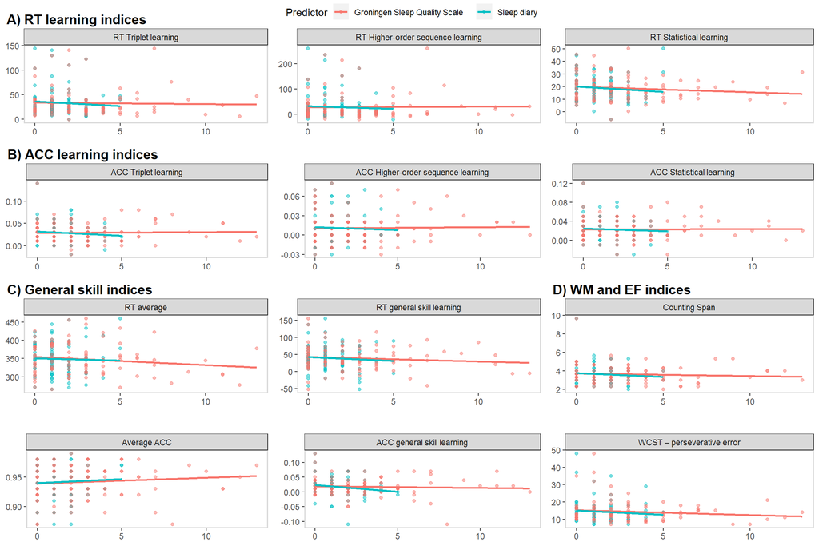

```r
plot2_df <-
  study2_long %>%
  mutate_at(.vars = vars(outcome_var, predictor_var),
            ~recode(., !!!variables_recode)) %>%
  unnest(cols = data)

# Create a plotting function for all groups separately
plot_double <- function(outcome_name){
  plot2_df %>%
    filter(outcome_var == outcome_name) %>%
    mutate_at(vars(outcome_var, predictor_var),
              ~recode(., !!!variables_recode)) %>%
    ggplot() +
    aes(x = pred_value, y = out_value, color = predictor_var) +
    geom_point(alpha = .5) +
    geom_smooth(method = "lm", se = FALSE) +
    facet_wrap(~outcome_var, scales = "free_y") +
    labs(title = NULL, x = NULL, y = NULL) +
    theme_bw() +
    theme(legend.position = "none",
          panel.grid.major = element_blank(),
          panel.grid.minor = element_blank(),
          panel.background = element_blank()) +
    cowplot::panel_border()
}

# Put all rows of the plot into a list

double_plots <-
  plot2_df %>%
  group_nest(outcome_var, keep = TRUE) %>%
  mutate(plot = map(data, ~plot_double(.x$outcome_var))) %>%
  pull(plot)

# Create one plot to get the legend
plot_2 <-
  plot2_df %>%
  filter(outcome_var == "RT Triplet learning") %>%
  ggplot() +
  aes(x = pred_value, y = out_value, color = predictor_var) +
  geom_point(alpha = .5) +
  geom_smooth(method = "lm", se = FALSE) +
  # scale_color_viridis_d() +
  labs(color = "Predictor") +
  theme(legend.direction = "horizontal",
        legend.justification = "right",
        legend.box.just = "top",
        legend.box.margin = margin())

# Get legend
plot_legend <- cowplot::get_legend(plot_2)

# Assemble the plot.
# I realize that the code is a bit ugly, but the outcome seems acceptable
plot_grid(
  NULL, plot_legend, NULL,
  double_plots[[11]], double_plots[[9]], double_plots[[10]],
  NULL, NULL, NULL,
  double_plots[[4]], double_plots[[2]], double_plots[[3]],
  NULL, NULL, NULL,
  double_plots[[7]], double_plots[[8]],double_plots[[6]],
  NULL, NULL, NULL,
  double_plots[[5]], double_plots[[1]], double_plots[[12]],
  labels = c(
    "", "", "",
    "A) RT learning indices", "", "",
    "", "", "",
    "B) ACC learning indices", "", "",
    "", "", "",
    "C) General skill indices", "", "D) WM and EF indices",
    "", "", "",
    "", "", ""),
  hjust = -.05,
  vjust = .05,
  nrow = 8,
  rel_heights = c(.20, 1, .15, 1, .15, 1, .15, 1)
) +
  geom_segment(y = .74, yend = .74, x = .02, xend = .98, size = 1.1) +
  geom_segment(y = .49, yend = .49, x = .02, xend = .98, size = 1.1) +
  geom_segment(y = .02, yend = .49, x = .668, xend = .668, size = 1.1) +
  NULL
```

# References

Bates, Douglas, Martin Mächler, Ben Bolker, and Steve Walker. 2015. “Fitting Linear Mixed-Effects Models Using lme4.” *Journal of Statistical Software* 67 (1): 51. https://doi.org/10.18637/jss.v067.i01.

Canty, Angelo, and B. D. Ripley. 2019. “boot: Bootstrap R (S-Plus) Functions.” https://cran.r-project.org/web/packages/boot/index.html.

Davison, A. C., and D. V. Hinkley. 1997. *Bootstrap methods and their application*. Cambridge: Cambridge University Press.

Wagenmakers, Eric-Jan. 2007. “A practical solution to the pervasive problems of p values.” *Psychonomic Bulletin & Review* 14 (5): 779–804. https://doi.org/10.3758/BF03194105.